# Homework 4 - GPS data and subsidence of the San Joaquin Valley

The example data we are going to use in this homework is from continuously operating high-precision GPS stations that are operated by UNAVCO which is a non-profit university-governed consortium that facilitates geoscience research and education using geodesy.

Let's get an introduction here: https://youtu.be/yxLMk120vMU

This data viewer gives a great summary velocity overview of the available GPS data: https://www.unavco.org/software/visualization/GPS-Velocity-Viewer/GPS-Velocity-Viewer.html

Let's look at data from a GPS station that is in Visalia California. Visalia is in the San Joaquin Valley between Fresno and Bakersfield.

https://www.unavco.org/instrumentation/networks/status/pbo/overview/P566

## Exercise 1 - recaping some basic Pandas and plotting functions

Today we will be focused on putting tools to use that we have used before with a couple new tricks related to dealing with time-series data.

### Using pandas to import and filter data

From the previous classes we have used the pandas library to import and filter data. The DataFrame object has been the most common way we have dealt with data.

We have used the `numpy` library of functions to make numerical and statistical calculations. In particular we have put the numpy array data structure to work for us.

```python
import pandas as pd
import numpy as np
```

One of the strengths of pandas is its ability to read and write different data types. For example, we have used the `pd.read_csv()` function to import .csv files throughout the course. This function can either be pointed to a file that is located on your computer (make sure your file path is correct!) or a file that is posted on the internet. There are some online databases where you can use a url to access data of your choosing using a special format (API). We took this approach to get our birthquakes earlier in the course.

Let's import daily data since 2005 for the Visalia California GPS station. The data is in the North American tectonic plate (NAM14) reference frame which means that it takes the interior eastern part of North America functions as a fixed and stable point.

```python
# P566_GPS_data = pd.read_csv('./data/P566.cwu.nam14.csv')
```

Let's look at the file.

It turns out that there are a bunch of header lines and the header row that contains the column names needs to be specified (`header = 11`).

**(2 points)** reload the data this time specifying `header = 11` in the `read_csv`` function

```python
## Add header = 11 to skip the first 11 rows
P566_GPS_data = pd.read_csv('./data/P566.cwu.nam14.csv', header=11)
```

We know how to take a peak at a DataFrame by applying the `.head()` function.

```python
P566_GPS_data.head()
```

|  | Date | North (mm) | East (mm) | Vertical (mm) | North Std. Deviation (mm) | East Std. Deviation (mm) | Vertical Std. Deviation (mm) | Quality | Unnamed: 8 |
| --- | --- | --- | --- | --- | --- | --- | --- | --- | --- |
| 0 | 2005-11-16 | 0.00 | 0.00 | 0.00 | 2.11 | 1.71 | 7.70 | repro | NaN |
| 1 | 2005-11-17 | 0.26 | -1.83 | 0.44 | 2.02 | 1.61 | 7.36 | repro | NaN |
| 2 | 2005-11-18 | 0.03 | -0.64 | 5.36 | 2.00 | 1.62 | 7.35 | repro | NaN |
| 3 | 2005-11-19 | 0.38 | -0.86 | 4.61 | 2.02 | 1.62 | 7.37 | repro | NaN |
| 4 | 2005-11-20 | -0.15 | -1.14 | -3.28 | 2.04 | 1.65 | 7.46 | repro | NaN |

We have done a lot where we have used extracted data from a single column. We have used the syntax `DataFrameName['column_name']`. It can be helpful to look at the available columns:

```python
P566_GPS_data.columns
```

```
Index(['Date', ' North (mm)', ' East (mm)', ' Vertical (mm)',
       ' North Std. Deviation (mm)', ' East Std. Deviation (mm)',
       ' Vertical Std. Deviation (mm)', ' Quality', 'Unnamed: 8'],
      dtype='str')
```

Some columns names have spaces before and after the name. To make it easier to work with the data, let's remove the spaces from the column names.

```python
P566_GPS_data.columns = P566_GPS_data.columns.str.strip()
```

Let first look at how this point is moving north with respect to stable North America.

```python
P566_GPS_data['North (mm)'].describe()
```

```
count    6305.000000
mean       81.556114
std        47.225855
min        -0.860000
25%        41.690000
50%        81.630000
75%       120.950000
max       167.900000
Name: North (mm), dtype: float64
```

By themselves these data are pretty cool. It looks like Visalia has moved north relative to stable North America by ~170 mm (17 cm) over the past 18 years (the data starts in November 2005).

### Pandas timeseries

Pandas is good at dealing with time series data. We need to make sure that the data type of the 'Date' column is a time series

```python
P566_GPS_data['Date'][0]
```

```
'2005-11-16'
```

```python
type(P566_GPS_data['Date'][0])
```

```
str
```

**(2 points)** Right now, pandas thinks that the values in the data column are strings (a sequence of characters) rather than datetime values. We can convert them to be datetime values using `pd.to_datetime`.

```python
## Use the pd.to_datetime function to convert the Date column to a datetime object\
P566_GPS_data['Date'] = pd.to_datetime(P566_GPS_data['Date'])
```

```python
P566_GPS_data['Date'][0]
```

```
Timestamp('2005-11-16 00:00:00')
```

```python
type(P566_GPS_data['Date'][0])
```

```
pandas.Timestamp
```

### Making plots using `matplotlib`

We have relied on `matplotlib` to make plots throughout the course which we have imported as follows:

```python
import matplotlib.pyplot as plt
```

### Plotting with pandas

One thing that you can do using pandas once you have imported matplotlib that we haven't done very much is use built-in plotting functions on the DataFrame. In this case we can use `.plot`.

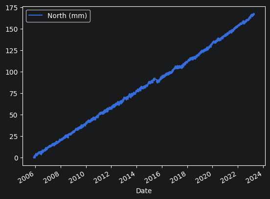

```python
P566_GPS_data.plot(x='Date', y='North (mm)')
```

### Plotting using plt functions

**(10 points)** Let's visualize both the north and east columns using `plt.plot()`. The data are from every day between Nov. 16, 2005 and now. i.e., create plots of North displacement vs time/date and East displacement vs time/date.

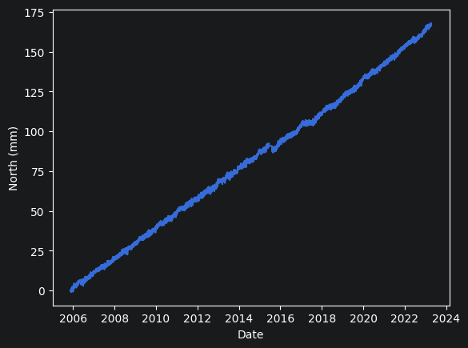

```python
## Create a plot between P566_GPS_data['Date'] and P566_GPS_data['North (mm)']
plt.plot(P566_GPS_data['Date'], P566_GPS_data['North (mm)'])
plt.xlabel("Date")
plt.ylabel("North (mm)")
```

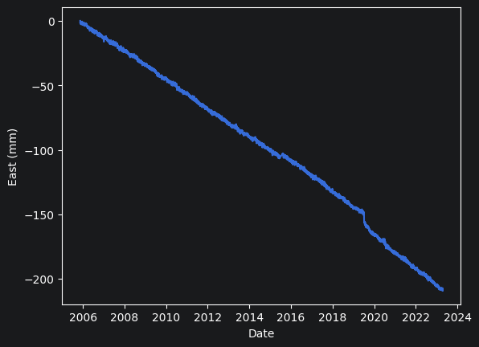

```python
## Create a plot between P566_GPS_data['Date'] and P566_GPS_data['East (mm)']
plt.plot(P566_GPS_data['Date'], P566_GPS_data['East (mm)'])
plt.xlabel("Date")
plt.ylabel("East (mm)")
```

What is going on with that drop midway through 2019? Let's take a look.

Through some trial and error, I found that the drop was between indices 4900 and 4950. Let's zoom in on that drop.

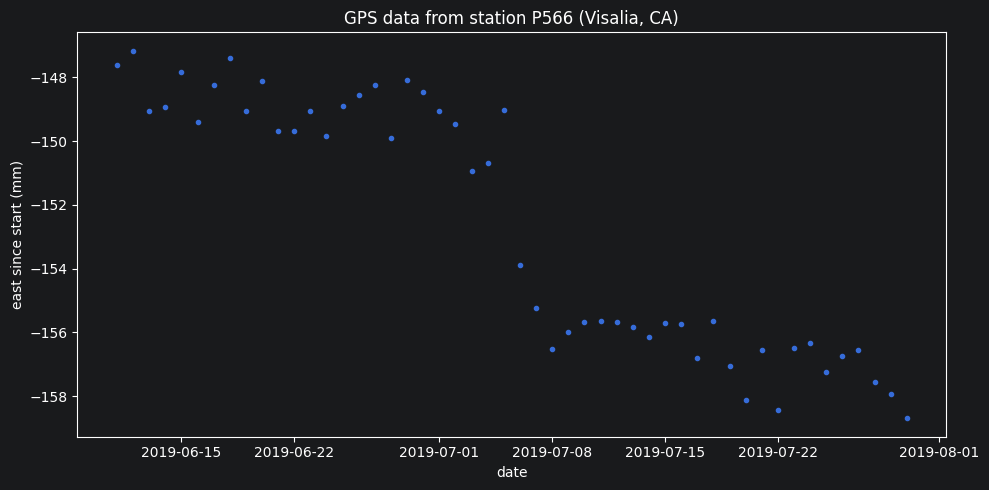

```python
plt.figure(figsize=(10,5))
plt.plot(P566_GPS_data['Date'][4900:4950],P566_GPS_data['East (mm)'][4900:4950],'.')
plt.ylabel('east since start (mm)')
plt.xlabel('date')
plt.title('GPS data from station P566 (Visalia, CA)')
plt.tight_layout()
plt.show()
```

**(5 points)** What happened on July 6, 2019? Add your answer to the cell below.

There was a big earthquake in California (Ridgecrest Earthquake). https://conservation.ca.gov/cgs/earthquakes/ridgecrest

https://earthquake.usgs.gov/earthquakes/eventpage/ci38457511/executive

## Exercise 2 - Fitting a line with scikit-learn

Scikit-learn has a function called `LinearRegression` that can be used to calculate best fit lines using the .fit() method. We have used this to fit lines to data in the past.

We can also consider higher order curves by using the `PolynomialFeatures` function in scikit-learn.

This function can be used to transform the data into a higher order polynomial space and then use the `LinearRegression` function to fit a line to the transformed data.

```python
from sklearn.linear_model import LinearRegression
```

We can calculate the number of days by making a new column in the data frame that is the 'date' value minus the initial date. This will be the number of days since the first date in the data set (Nov. 16 2005).

```python
P566_GPS_data['days'] = (P566_GPS_data['Date'] - P566_GPS_data['Date'][0])/np.timedelta64(1,'D')
```

Let's take a look at our DataFrame and make sure it has a new column `days` and that the column looks good.

```python
P566_GPS_data.head()
```

|  | Date | North (mm) | East (mm) | Vertical (mm) | North Std. Deviation (mm) | East Std. Deviation (mm) | Vertical Std. Deviation (mm) | Quality | Unnamed: 8 | days |
| --- | --- | --- | --- | --- | --- | --- | --- | --- | --- | --- |
| 0 | 2005-11-16 | 0.00 | 0.00 | 0.00 | 2.11 | 1.71 | 7.70 | repro | NaN | 0.0 |
| 1 | 2005-11-17 | 0.26 | -1.83 | 0.44 | 2.02 | 1.61 | 7.36 | repro | NaN | 1.0 |
| 2 | 2005-11-18 | 0.03 | -0.64 | 5.36 | 2.00 | 1.62 | 7.35 | repro | NaN | 2.0 |
| 3 | 2005-11-19 | 0.38 | -0.86 | 4.61 | 2.02 | 1.62 | 7.37 | repro | NaN | 3.0 |
| 4 | 2005-11-20 | -0.15 | -1.14 | -3.28 | 2.04 | 1.65 | 7.46 | repro | NaN | 4.0 |

**(5 points)** Now we can do a linear regression between the days (`P566_GPS_data['days']`) and the distance traveled north (`P566_GPS_data['North (mm)']`)

```python
## Define and fit a linear regression model using the 'days' column as the independent variable and the 'North (mm)' column as the dependent variable
## Hint: the independent variable should be a 2D array, you should use double brackets [[]] to select the column
model_north = LinearRegression()
model_north.fit(P566_GPS_data[['days']], P566_GPS_data['North (mm)'])
```

```
LinearRegression()
```

**(2 points)** We can get the best fitting slope and intercept of the line using the `.coef_` and `.intercept_` attributes of the `LinearRegression` object.

```python
## Retrieve the slope and intercept from the model
slop, intercept = model_north.coef_[0], model_north.intercept_
```

```python
print(f'The slope is {slop:.2f} and the intercept is {intercept:.2f}')
```

```
The slope is 0.03 and the intercept is 0.25
```

**(2 points)** What are the units of this slope? Write your answer in the cell below.

mm / day

### Make a plot of prediction

**(5 points)** Plot a best-fit line for the data. *Recall that you can use model.predict() to predict the values of the best-fit line.*

```python
## Predict the dependent variable based on the independent variable 'days'
y_pred = model_north.predict(P566_GPS_data[['days']])
```

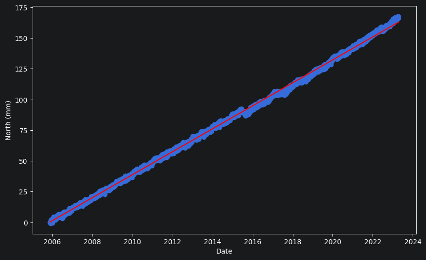

```python
## Plot both the data 'North (mm)' and the model 'y_pred' on the same plot. Using the 'Date' column as the x-axis
## Create a plot between P566_GPS_data['Date'] and P566_GPS_data['North (mm)']
plt.figure(figsize=(10, 6))
plt.scatter(P566_GPS_data['Date'], P566_GPS_data['North (mm)'])
plt.plot(P566_GPS_data['Date'], y_pred, color='red')

plt.xlabel('Date')
plt.ylabel('North (mm)')
plt.show()
```

**(5 points)** Calculate and plot the residual. *Recall that the residual is the difference between the actual data and the values obtained with the linear model.*

```python
## Calculate the residuals between the data 'North (mm)' and the model prediction y_pred.
residuals = P566_GPS_data['North (mm)'] - y_pred
```

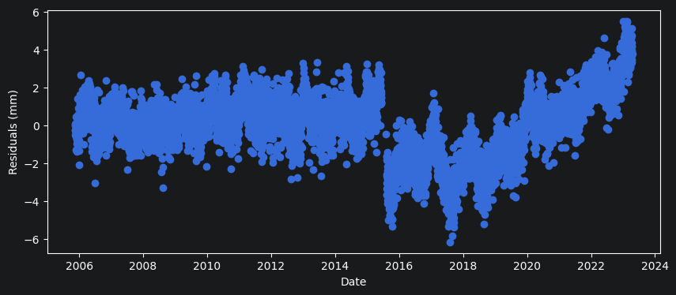

```python
## Plot the residuals over Date.
plt.figure(figsize=(10, 4))
plt.scatter(P566_GPS_data['Date'], residuals)
plt.xlabel('Date')
plt.ylabel('Residuals (mm)')
```

**(2 points)** Using your results predict how far north (relative to stable North America) the Visalia station will go in the next 10 years *There are 365.25 days in a year.*

```python
print(f"{model_north.coef_[0] *  10 * 365.25:.2f} mm for north in 10 yrs")
```

```
93.50 mm for north in 10 yrs
```

## Exercise 3 - Evaluating the model using $R^{2}$

We'd also like to know who well this model fits our data (i.e. how correlated the data are). The $R^{2}$ correlation coefficient can be helpful in this regard. $R^{2}$ is zero for uncorrelated data, and 1 for perfectly linear data (so no misfit between the model line and data).

**(5 points)** Let's calculate the $R^{2}$ value for our model. Recall that the $R^{2}$ value is calculated as follows:

$$R^{2} = 1 - \frac{\sum_{i=1}^{n} (y_{i} - \hat{y}_{i})^{2}}{\sum_{i=1}^{n} (y_{i} - \bar{y})^{2}}$$

where $y_{i}$ is the actual data, $\hat{y}_{i}$ is the prediction, and $\bar{y}$ is the mean of the actual data.

```python
## Calculate the R^2 value for the model
model_north.score(P566_GPS_data[['days']], P566_GPS_data['North (mm)'])
```

```
0.998778874919735
```

### Defining a function

When you may be doing a calculation more than once it is a good idea to define a function. Let's define a function that will take an east magnitude and a north magnitude and return a direction between 0 and 360.

```python
def GPS_direction(east_magnitude, north_magnitude):
    direction_rad = np.arctan2(east_magnitude, north_magnitude)
    direction = np.rad2deg(direction_rad) % 360
    return direction
```

```python
GPS_direction(0,-1)
```

```
np.float64(180.0)
```

Let's repeat the process above (calculating a regression slope) for the east data.

**(15 points)** Calculate the slope for the east data. Use this slope and the slope for the north data to calculate the direction of the motion of the station using the `GPS_direction` function.

```python
## Define and fit a linear regression model using the 'days' column as the independent variable and the 'East (mm)' column as the dependent variable
model_east = LinearRegression()
model_east.fit(P566_GPS_data[['days']], P566_GPS_data['East (mm)'])
```

```
LinearRegression()
```

```python
### Retrieve the slope and intercept from the model
slop_east, intercept_east = model_east.coef_[0], model_east.intercept_
```

Based on estimation of east and north slope, we can calculate the direction of the motion of the station.

```python
# To make it clear, let's redefine the slope and intercept for the North component
slop_north, intercept_north = model_north.coef_[0], model_north.intercept_

# calculate the direction of motion
direction = GPS_direction(slop_east, slop_north)
```

## Making a map with `cartopy`

Let's define variables giving the latitude and longitude of the P566 GPS station.

```python
P566_lat = 36.32445
P566_lon = -119.22929
```

[figure not shown]

```python
import matplotlib.pyplot as plt
import cartopy.crs as ccrs
import cartopy.feature as cfeature
import cartopy.io.img_tiles as cimgt

# Replace these variables with your station's longitude and latitude
P566_lon = -120.0  # Example longitude of station P566
P566_lat = 37.0    # Example latitude of station P566

# Add a background image from Google Maps
tiles = cimgt.GoogleTiles()

# Set up the map
plt.figure(figsize=(10, 10))
ax = plt.axes(projection=tiles.crs)
ax.set_extent((-125, -114, 32, 42.5))  # Set the geographical extent (lon_min, lon_max, lat_min, lat_max)

# Instread of adding features, we add the Google Maps image
# ax.add_feature(cfeature.LAND)
# ax.add_feature(cfeature.OCEAN)
# ax.add_feature(cfeature.STATES)

# Add the Google Maps image to the map
ax.add_image(tiles, 6) # The number 6 is the zoom level. The higher the number, the closer in you zoom

# Plot the station's location
ax.scatter(P566_lon, P566_lat, transform=ccrs.PlateCarree(), color='red', s=50, label='P566 Station')

# Annotate the station with its name
ax.text(P566_lon, P566_lat, 'P566\nstation\n', transform=ccrs.PlateCarree(),
        color='red', horizontalalignment='center', verticalalignment='bottom', size=12)

# Annotation for the direction of motion using an arrow
ax.arrow(P566_lon, P566_lat, np.sin(np.deg2rad(direction)), np.cos(np.deg2rad(direction)), head_width=0.1, head_length=0.1, fc='blue', ec='blue', transform=ccrs.PlateCarree())

plt.legend()
plt.show()
```

[figure not shown]

**(2 points)** Does the direction of motion of the station you calculated match the direction of the Pacific Plate relative to North America? Write your answer in the cell below.

Yes! To the North-West.

## Exercise 4 - Vertical component of GPS time-series

We have been looking at the north and east components of the GPS time-series. Let's take a look at the vertical component of the GPS time-series.

**(5 points)** Create a plot of the vertical displacement against time (date or days)

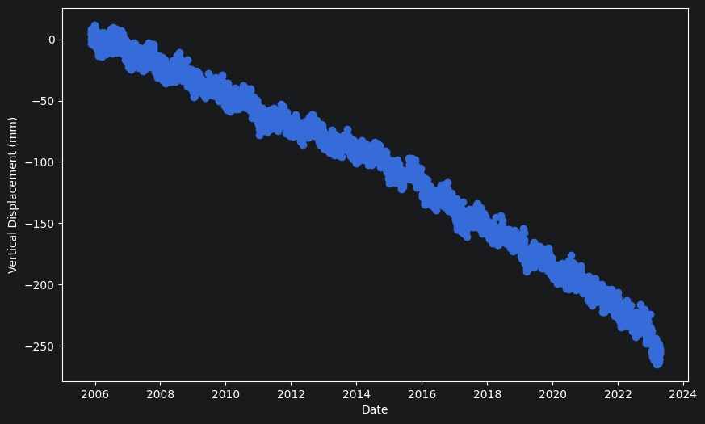

```python
## Create a plot between P566_GPS_data['Date'] and P566_GPS_data['Vertical (mm)']
plt.figure(figsize=(10, 6))

plt.scatter(P566_GPS_data['Date'], P566_GPS_data['Vertical (mm)'])

plt.xlabel('Date')
plt.ylabel('Vertical Displacement (mm)')
```

**(2 points)** What do these data show? What is happening to the land surface? Why? Add your answer to the cell below.

Subsidence (going downward; sinking) of the land, because of overpumping of groundwater.

https://earthobservatory.nasa.gov/images/89761/san-joaquin-valley-is-still-sinking

https://www.earthdate.org/californias-sinking-valley

This is a big problem for the San Joaquin Valley. So is the rate of land subsidence increasing? Specifically, was the rate of land subsidence greater during the last 5 years (2018-01-01 and 2023-01-01) than it was in the first 5 years of the record (2006-01-01 and 2011-01-01)?

To answer this question, we need to:

- Filter the DataFrame to only include those years
- Calculate the slope of the regression line for each time period.
- Compare the the slopes between the two age ranges. Which one appears to be greater? Is this result significant or do they have overlapping confidence bounds?

Let's look at a subset of the data for the 5 years between 2018-01-01 and 2023-01-01. We have done a lot of this filtering using pandas. However, the syntax is hard to remember.

It can be helpful to remember how this is actually working under the hood. When we are passing in a conditional statement like `P566_GPS_data['Date'] >= '2006-01-01'` we are asking pandas to tell us, at every value in the `P566_GPS_data['Date']` column is it true or false that the date is greater than 2018-01-01?

```python
P566_GPS_data['Date'] >= '2018-01-01'
```

```
0       False
1       False
2       False
3       False
4       False
        ...
6300     True
6301     True
6302     True
6303     True
6304     True
Name: Date, Length: 6305, dtype: bool
```

The result is a list of true/false values. We then use these true/false values to filter the values in the DataFrame only returning those that are true. We can link multiple conditionals together with the `&` symbol such as in the example below:

```python
P566_GPS_18_23 = P566_GPS_data[(P566_GPS_data['Date'] >= '2018-01-01') & (P566_GPS_data['Date'] < '2023-01-01')]
P566_GPS_18_23.head()
```

|  | Date | North (mm) | East (mm) | Vertical (mm) | North Std. Deviation (mm) | East Std. Deviation (mm) | Vertical Std. Deviation (mm) | Quality | Unnamed: 8 | days |
| --- | --- | --- | --- | --- | --- | --- | --- | --- | --- | --- |
| 4374 | 2018-01-01 | 111.65 | -132.47 | -156.00 | 1.86 | 1.55 | 6.83 | repro | NaN | 4429.0 |
| 4375 | 2018-01-02 | 112.04 | -132.45 | -158.25 | 1.87 | 1.54 | 6.79 | repro | NaN | 4430.0 |
| 4376 | 2018-01-03 | 111.85 | -132.73 | -155.05 | 1.88 | 1.55 | 6.83 | repro | NaN | 4431.0 |
| 4377 | 2018-01-04 | 110.52 | -131.16 | -160.25 | 1.90 | 1.56 | 6.91 | repro | NaN | 4432.0 |
| 4378 | 2018-01-05 | 111.68 | -132.28 | -156.70 | 1.87 | 1.54 | 6.79 | repro | NaN | 4433.0 |

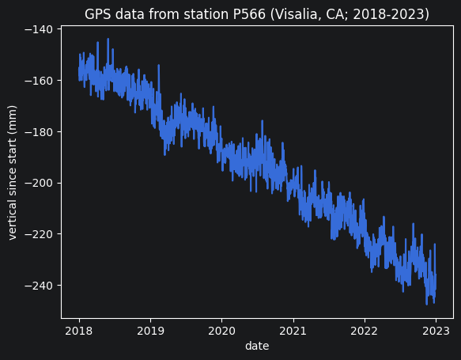

```python
plt.figure()
plt.plot(P566_GPS_18_23['Date'],P566_GPS_18_23['Vertical (mm)'])
plt.ylabel('vertical since start (mm)')
plt.xlabel('date')
plt.title('GPS data from station P566 (Visalia, CA; 2018-2023)')
plt.show()
```

**(10 points)** Create a second new DataFrame containing only the data between 2006 and the start of 2011. Plot this data against the date.

```python
## Let's do the same for the period 2006-2011
P566_GPS_06_11 = P566_GPS_data[(P566_GPS_data['Date'] >= '2006-01-01') & (P566_GPS_data['Date'] < '2011-01-01')]
P566_GPS_06_11.head()
```

|  | Date | North (mm) | East (mm) | Vertical (mm) | North Std. Deviation (mm) | East Std. Deviation (mm) | Vertical Std. Deviation (mm) | Quality | Unnamed: 8 | days |
| --- | --- | --- | --- | --- | --- | --- | --- | --- | --- | --- |
| 46 | 2006-01-01 | 2.37 | -2.75 | 4.95 | 2.19 | 1.80 | 8.02 | repro | NaN | 46.0 |
| 47 | 2006-01-02 | 0.65 | -2.49 | 7.68 | 2.11 | 1.68 | 7.51 | repro | NaN | 47.0 |
| 48 | 2006-01-03 | 1.98 | -2.50 | 4.52 | 2.32 | 2.02 | 8.48 | repro | NaN | 48.0 |
| 49 | 2006-01-04 | 1.91 | -1.75 | -0.37 | 2.26 | 1.96 | 8.32 | repro | NaN | 49.0 |
| 50 | 2006-01-05 | 2.94 | -1.34 | -4.20 | 2.13 | 1.78 | 7.71 | repro | NaN | 50.0 |

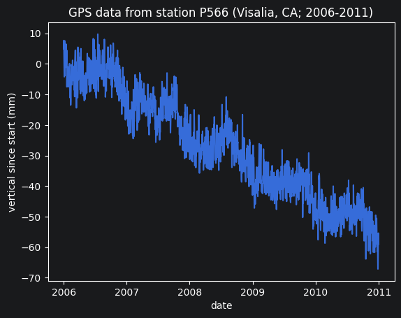

```python
plt.figure()
plt.plot(P566_GPS_06_11['Date'],P566_GPS_06_11['Vertical (mm)'])
plt.ylabel('vertical since start (mm)')
plt.xlabel('date')
plt.title('GPS data from station P566 (Visalia, CA; 2006-2011)')
plt.show()
```

Now we can build a linear model for the 2006-2011 data and the 2018-2023 data. So that we can compare the slopes of these two models to see if the rate of land subsidence has increased.

**(10 points)** complete the code cells below to create linear models for the land subsidence across each time period. Calculate (and print) the slope and intercept for each model.

```python
## Define and fit a linear regression model using P566_GPS_18_23['days'] and P566_GPS_18_23['Vertical (mm)']
model_18_23 = LinearRegression()
model_18_23.fit(P566_GPS_18_23[['days']], P566_GPS_18_23['Vertical (mm)'])

## Retrieve the slope and intercept from the model
slop_18_23, intercept_18_23 = model_18_23.coef_[0], model_18_23.intercept_
print(f'The slope is {slop_18_23:.2f} and the intercept is {intercept_18_23:.2f} for the period 2018-2023')
```

```
The slope is -0.05 and the intercept is 53.79 for the period 2018-2023
```

```python
## Define and fit a linear regression model using P566_GPS_06_11['days'] and P566_GPS_06_11['Vertical (mm)']
model_06_11 = LinearRegression()
model_06_11.fit(P566_GPS_06_11[['days']], P566_GPS_06_11['Vertical (mm)'])

## Retrieve the slope and intercept from the model
slop_06_11, intercept_06_11 = model_06_11.coef_[0], model_06_11.intercept_
print(f'The slope is {slop_06_11:.2f} and the intercept is {intercept_06_11:.2f} for the period 2006-2011')
```

```
The slope is -0.03 and the intercept is 2.67 for the period 2006-2011
```

We now have estimates for the slope of each time period, but what we need to do to finalize this analysis is determine whether or not these slope estimates are significantly different from each other.

**(10 points)** calculate the uncertainty in the slope parameter for the 2006 - 2011 time series. Use the code I've provided for the 2018 - 2023 time series to help you do this. Are the slopes of the two periods siginficantly different from each other? Is there a change in the land subsidence rate through time?

Remember (from lectures), the standard error of the slope for linear regression is:

$$ SE_{s} = \sqrt{\sigma^2 / \sum{(x_{i} - \bar{x})}^2} $$

where $\sigma^2 = \sum{(y_i - \hat{y}_i)^2}/(n-p) $ and $n$ is the number of observations, $p$ is the number of predictors. Together $n - p$ equals the 'degrees of freedom' $dof$.

The standard error of the intercept can then be given by:

$$ SE_{I} = \sqrt{\sigma^2(1/n + \bar{x}^2/\sum{(x_i - \bar{x})**2})} $$

Remember $\bar{x}$ indicates the mean value of $x$ and $\hat{y}_i$ indicates the predicted value of $y$ at position $i$.

```python
X = P566_GPS_18_23['days']
n = len(X)
p = len(model_18_23.coef_) + 1
dof = n - p
y = P566_GPS_18_23['Vertical (mm)']
y_pred = model_18_23.predict(X.values.reshape(-1,1))

sigma = np.sum((y - y_pred)**2) /dof

se_slope = np.sqrt(sigma/np.sum((X - X.mean())**2))
se_inter = np.sqrt(sigma * (1/n + (X.mean()**2)/np.sum((X - X.mean())**2)))

print(f"Standard error of slope: {se_slope:.4f}")
print(f"Standard error of intercept: {se_inter:.4f}")
```

```
Standard error of slope: 0.0002
Standard error of intercept: 1.1775
```

```python
X_06_11 = P566_GPS_06_11['days']
n_06_11 = len(X_06_11)
p_06_11 = 2
dof_06_11 = n_06_11 - p_06_11
y_06_11 = P566_GPS_06_11['Vertical (mm)']
y_pred_06_11 = model_06_11.predict(X_06_11.values.reshape(-1, 1))

sigma_sq_06_11 = np.sum((y_06_11 - y_pred_06_11)**2) / dof_06_11

se_slope_06_11 = np.sqrt(sigma_sq_06_11 / np.sum((X_06_11 - X_06_11.mean())**2))
se_inter_06_11 = np.sqrt(sigma_sq_06_11 * (1/n_06_11 + (X_06_11.mean()**2) / np.sum((X_06_11 - X_06_11.mean())**2)))

print(f"2006-2011 Standard error of slope: {se_slope_06_11:.4f}")
print(f"2006-2011 Standard error of intercept: {se_inter_06_11:.4f}")
```

```
2006-2011 Standard error of slope: 0.0002
2006-2011 Standard error of intercept: 0.2462
```

Yes, the slopes of the two periods are significantly different from each other.

Also, there is a change in the land subsidence rate through time.

**(2 points)** What is the main economic activity around P566? And what resources does that activity require?

Agriculture, which requires massive amount of water.

**(2 points)** What does the vertical component of the GPS time-series tell us about the land movement in the San Joaquin Valley when comparing the periods 2006-2011 and 2018-2023?

The slope is getting steeper (-0.03 b/w 2006-2011 -> -0.05 b/w 2018-2023). This shows the speed of the land subsidence is accelerated.

[figure not shown]